# Debriefing

Session 1

Luis F. Gómez L.

luis.gomezl@unimilitar.edu.co

Distance Learning Faculty

8 September, 2026

# Please Read Me

- This presentation is based on (Program on Negotiation, 2008)
- **Purpose**
  - Discuss negotiation performance, share feedback, and identify key learning points during the debrief

# Resource imbalances and the relationship among the parties

- There is a disparity between the resources controlled by each role
  - A control more resources than B
  - B control more resources than C

  $$A > B > C$$
- For this reason, roles must be randomly assigned to ensure fairness

# Types of agreements

| A | B | C |
| --- | --- | --- |
| 59 | 59 | 0 |
| 60 | 58 | 0 |
| 60 | 60 | 1 |
| 59 | 59 | 3 |

Table 2: Agreements which tend to have an equally distribution of points

| A | B | C |
| --- | --- | --- |
| 121/3 | 121/3 | 121/3 |
| 41 | 40 | 40 |
| 43 | 40 | 38 |

Table 3: Agreements according to the control of resources

| A | B | C |
| --- | --- | --- |
| 60 | 40 | 21 |
| 50 | 40 | 31 |

- Other agreements
  - A became so greedy so B and C exclude A
  - C blocks the coalition between A and B and chooses to work with A[^1]

# Stability of coalitions

- A: 59, B: 59
  - C is excluded
- Counter offer by C: A: 60, C: 24
  - B is excluded
- Counter offer by B: A: 61, B: 57
  - C is excluded
- Counter offer by C: A: 62, A: 22
  - B is excluded

**It is possible to prove that in this game any coalition can be brake**

# Fairness criteria

- Possible states in case of agreement

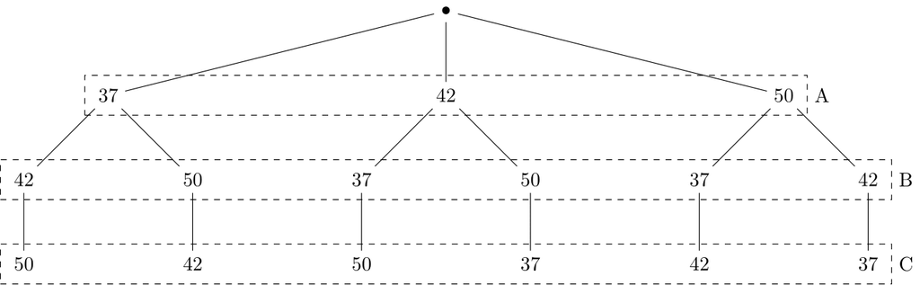

Figure 1: Scenarios in the game if an agreement is reached

[figure not shown]

Figure 2: Jeremy Bentham

- Benthamite social welfare function
  - $G_i$: grade of student $i$

$$\max \frac{1}{n}G_1 + \cdots \frac{1}{n}G_n = \max \sum_{i = 1}^n \frac{1}{n}G_i$$

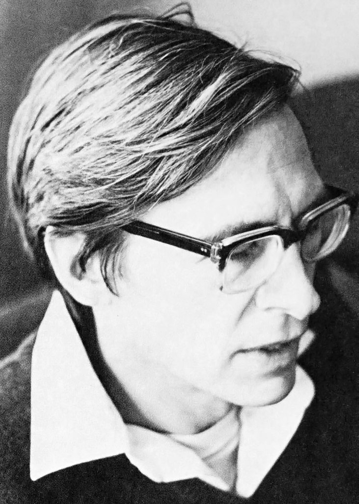

Figure 3: John Rawls

- Rawlsian social welfare function
  - $G_i$: grade of student $i$

$$\max \min \{ G_1, \ldots, G_m \}$$

# Acknowledgments

- To my family that supports me
- To the taxpayers of Colombia and the [**UMNG students**](https://www.umng.edu.co/estudiante) who pay my salary
- To the [**Business Science**](https://www.business-science.io/) and [**R4DS Online Learning**](https://www.rfordatasci.com/) communities where I learn [**R**](https://www.r-project.org/about.html) and [**$\pi$-thon**](https://www.python.org/about/)
- To the [**R Core Team**](https://www.r-project.org/contributors.html), the creators of [**RStudio IDE**](https://posit.co/download/rstudio-desktop/), [**Positron**](https://positron.posit.co/), [**Quarto**](https://quarto.org/) and the authors and maintainers of the packages [**tidyverse**](https://CRAN.R-project.org/package=tidyverse), [**gt**](https://CRAN.R-project.org/package=gt) and [**tinytex**](https://CRAN.R-project.org/package=tinytex) for allowing me to access these tools without paying for a license

# References

Program on Negotiation. (2008). *Three Party Coalition Exercise - Game Theory and Negotiation Analytics Role-Play* (Harvard Law School, Ed.).

## Footnotes

[^1]: Less common agreement